# Block Group CARR Description

Author

Kate Nelson & Tuan Nguyen

Published

September 27, 2024

## Block Group CARR (the “Original”)

The CARR (Community assets and relative rurality) index is a continuous, multidimensional measure of rurality based on the concept of sustainable development that integrates measures of environmental, social, and economic resources. The index incorporates traditional rurality measures such as population density, distance from metropolitan areas, and developed area with measures of availability and accessibility of 70 different infrastructure types that support essential community services and community amenities. The index uses data last updated in 2019 and was originally constructed for census block-groups in the coterminous United States. The original dataset (K. Nelson and Nguyen 2022) can be found at Zenodo and was extensively described in an article in the *Journal of Rural Studies* (K. S. Nelson and Nguyen 2023). This descriptive document is provided solely for convenient comparison with CARR variants at alternate spatial scales. Please cite the original article (K. S. Nelson and Nguyen 2023) rather than this document.

The values of the block group CARR scores fall within the original range of CARR scores (0-1), where a value of 0 means very urban with high concentrations of services and amenities and a value of 1 means very rural with low concentrations of services and amenities. The mean value is ~**0.5**.

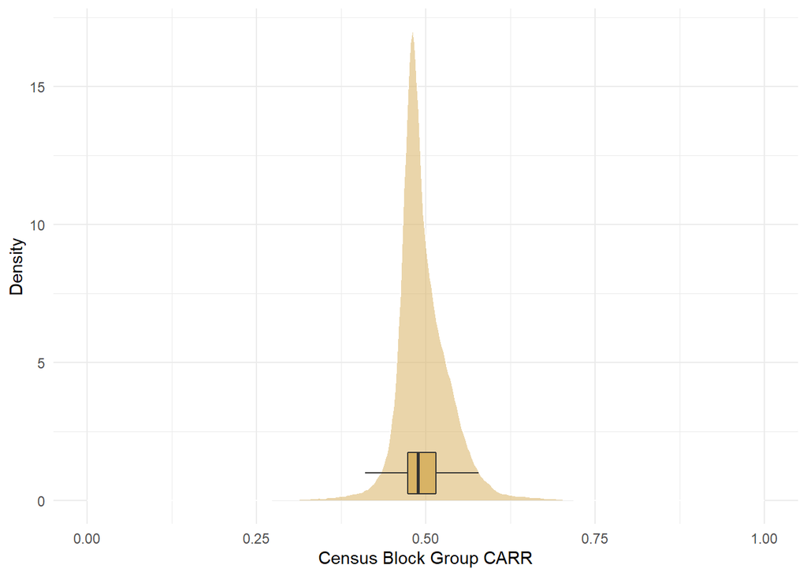

The spatial distribution of CARR across U.S. census block groups is shown below.

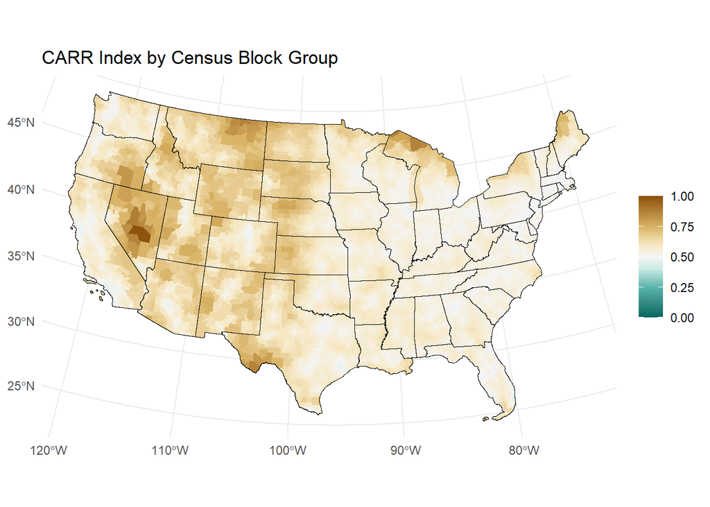

Index values indicate generally higher values of CARR in census designated rural areas but with a large degree of overlap in urban and rural CARR scores.

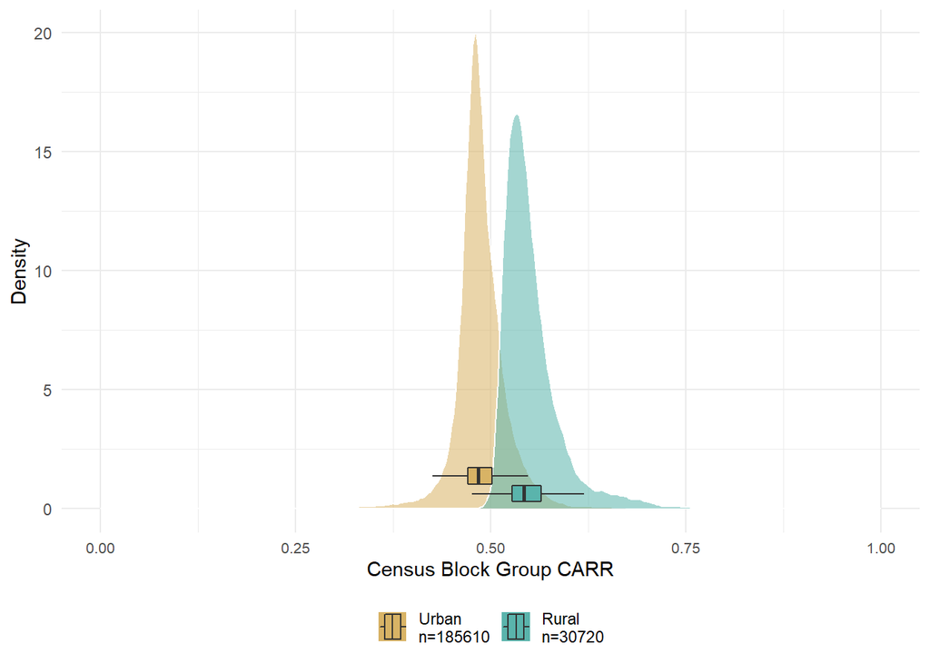

In addition, the census block group CARR scores generally tend to increase with increasing rurality in terms of RUCC but with large amounts of overlap.

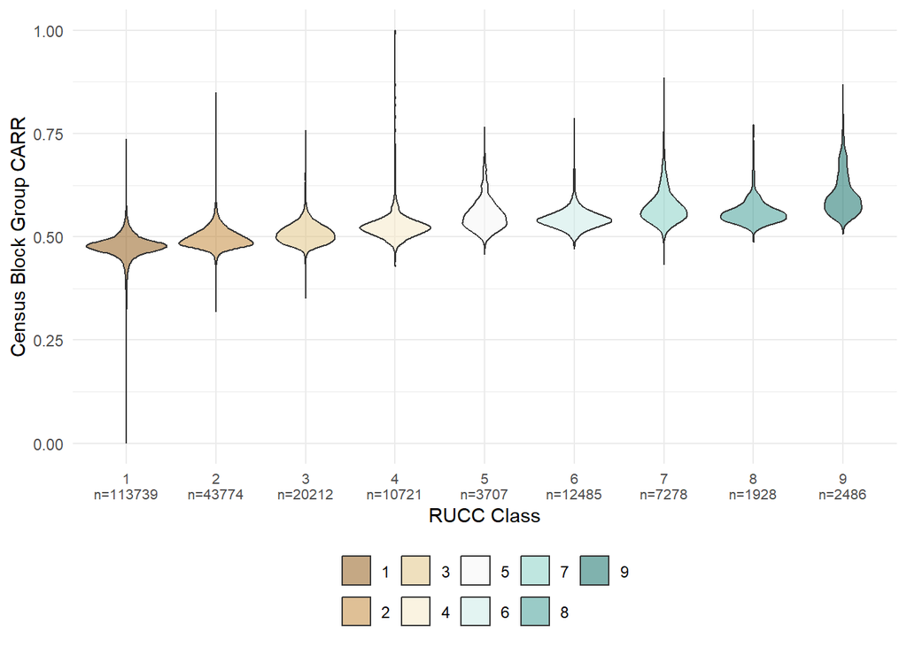

The availability component spatial distribution is provided below. Larger values of this component, which has an inverse relationship to the final CARR score, are associated with greater density of services and amenities and are generally found in more developed metropolitan areas. *Note that this component has a highly skewed distribution and is log transformed for visualization purposes.*

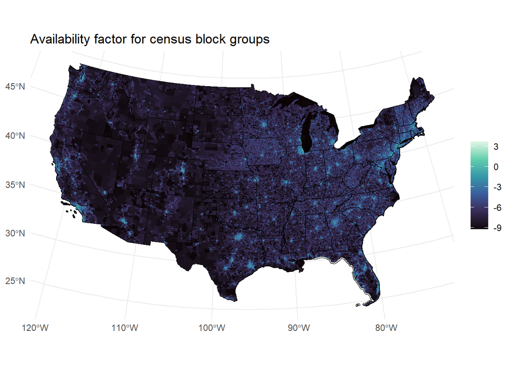

The three accessibility components’ spatial distributions are shown below. Larger values of the first accessibility factor are associated with greater distances to amenities. Larger values of the second accessibility factor are associated with increased distance to essential services. Larger values of the third accessibility factor are associated with greater distances to both amenities and natural resource extraction (e.g. peri-urban).

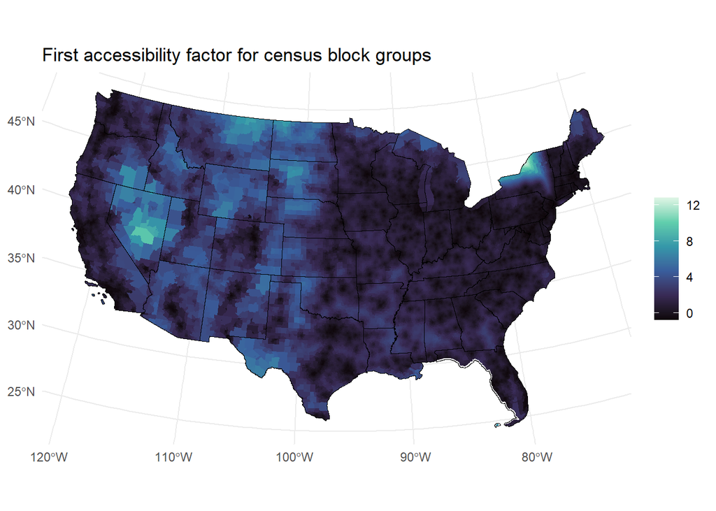

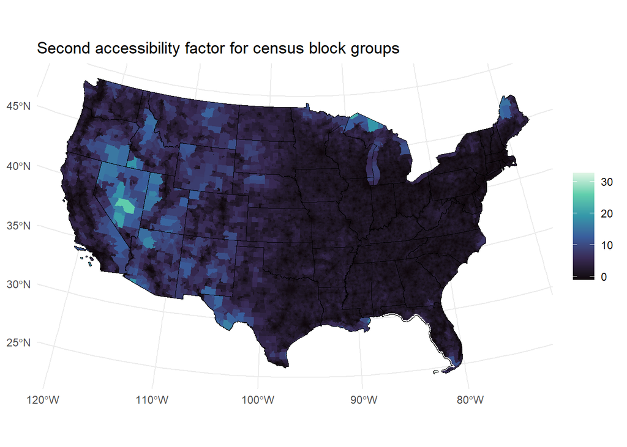

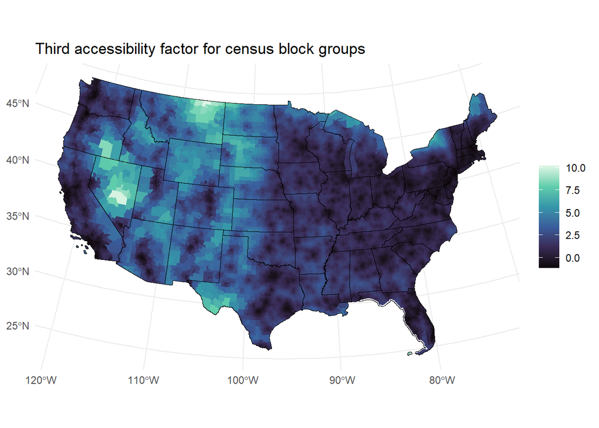

We also see that the relationships between census block group CARR and population density, distance to metro areas, and developed land cover meet expectations. CARR has a negative relationship with population density and developed land cover and a positive relationship with distance to metro areas.

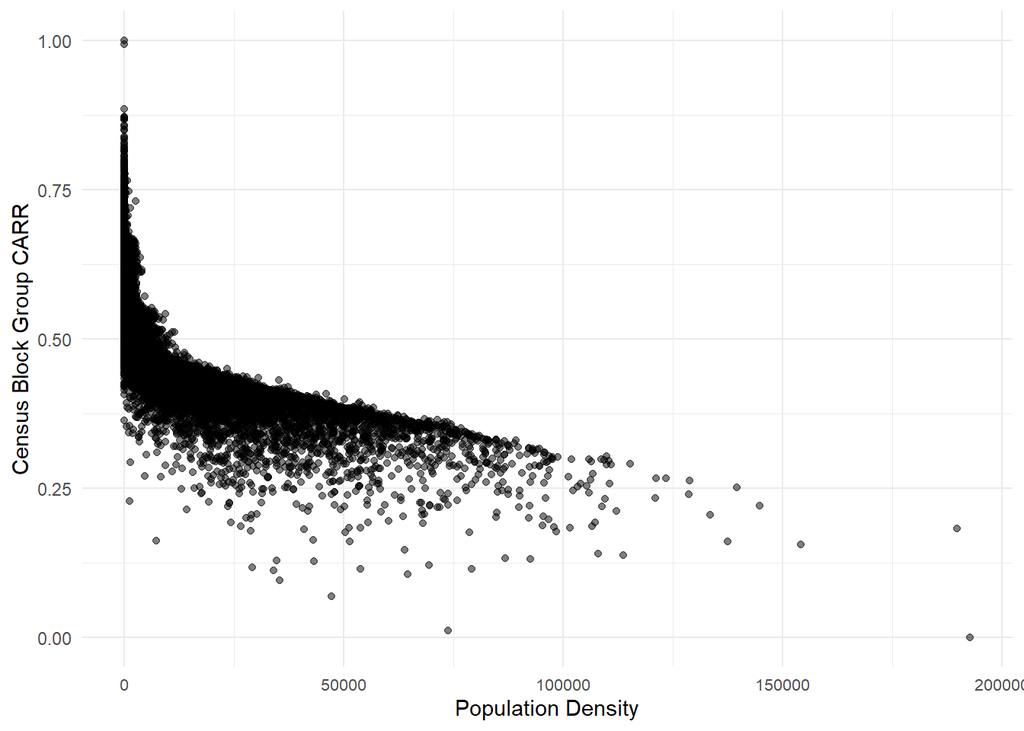

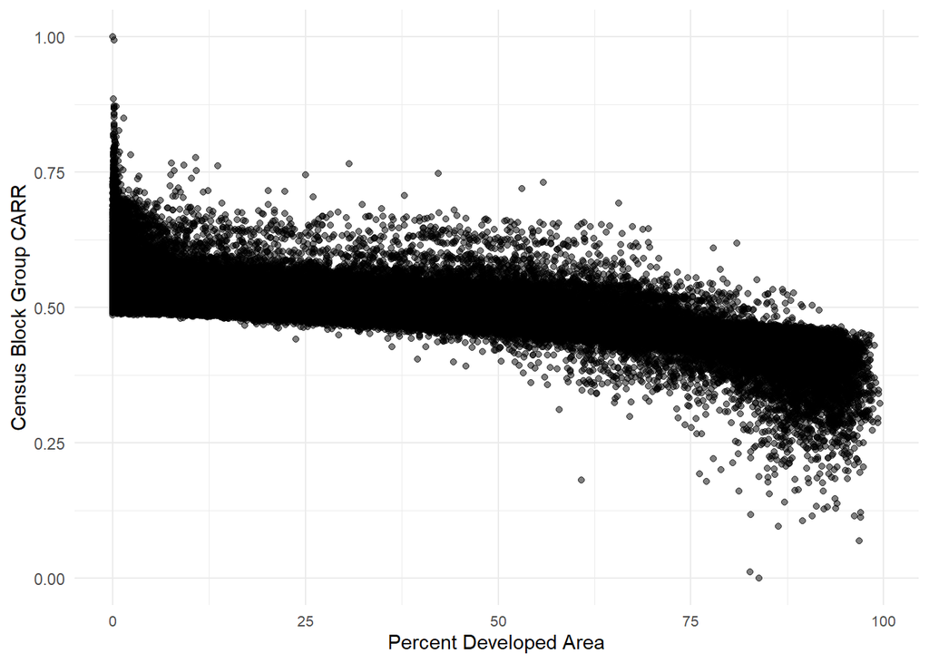

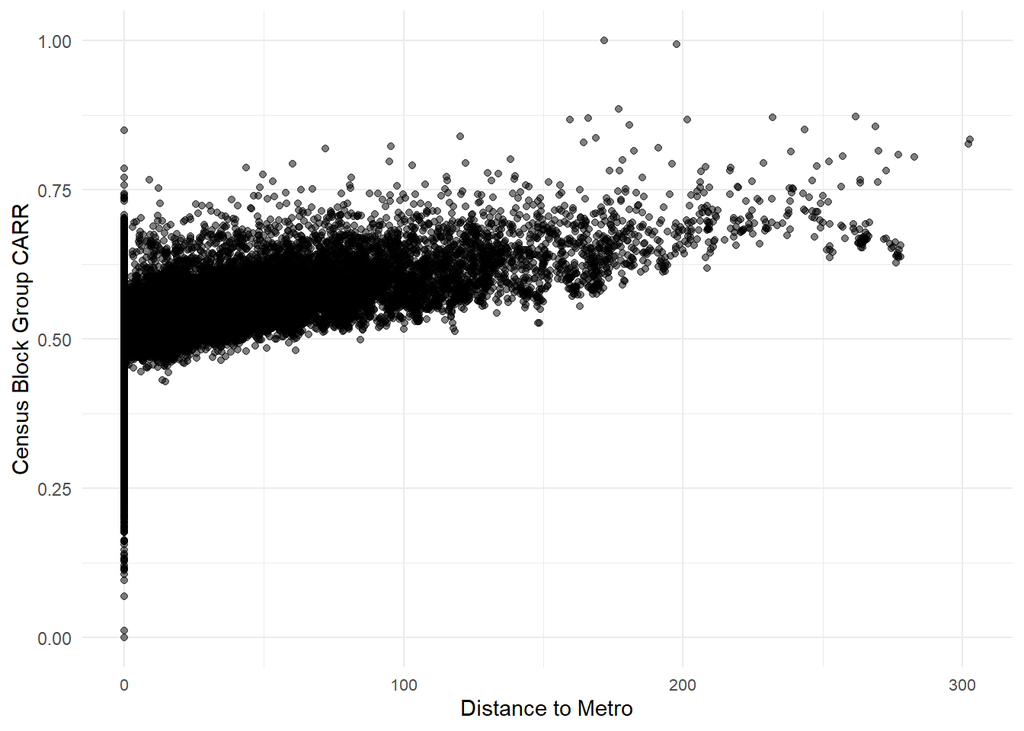

## References

Nelson, Katherine S., and Tuan D. Nguyen. 2023. “Community Assets and Relative Rurality Index: A Multi-Dimensional Measure of Rurality.” *Journal of Rural Studies* 97 (January): 322–33. https://doi.org/10.1016/j.jrurstud.2022.12.025.

Nelson, Katherine, and Tuan Nguyen. 2022. “Community Assets and Relative Rurality Index.” Zenodo. https://doi.org/10.5281/ZENODO.8072187.